# P2

```python
import numpy as np
import matplotlib.pyplot as plt
%matplotlib inline
```

**Aluno**: Tibor Zequini Boglár, **NUSP**: 9302312

**Exercício 1.1**

**(a)** Solve the widow's problem: Thisted considers historic data on widows and their dependent children from aSwedishpensionfund.If $y_k$ denotes the number of widows with $k$ children,then the data values are $y0=3062$,$y_1=587$,$y_2=284$,$y_3=103$,$y_4=33$,and $y_5=4$,and $y_6=2$.

The fact that most widows have no dependent children suggests that a simple Poisson model would give a poor fit.A better model is a mixture of a population of widows with no children, population $A$,and a population of widows having a Poisson number of children, population $B$.

Suppose a widow falls into population $A$ with probability $p$ and into population $B$ with probability $1−p$.

Let $\mu$ be the mean of the Poisson distribution characterizing population $B$.

**R:** Seja $Y$ a variável aleatória que representa o número de filhos, então sabe-se que,

$$P(Y=0) = p + (1-p) e^{-\mu}$$

E também que, $$P(Y = y) = (1-p) \frac{\mu^ye^{-\mu}}{y!}, \text{ com } y>0.$$

Portanto, a função de verossimilhança pode ser escrita como

$$L(Y|\theta) = \prod_{y=0}^6 g(y|\theta)=g(y=0|\theta)^{y_0}\prod_{k=1}^6g(y=k|\theta)^{y_k}$$$$L(Y|\theta)= \left(p + (1-p)e^{-\mu}\right)^{y_0} \prod_{k=1}^6 \left((1-p)\frac{\mu^{k}e^{-\mu}}{k!}\right)^{y_k}$$

E tirando o logaritmo da função de verossimilhança, acabamos com,

$$\log(Y|\theta)= y_0 \log \left(p + (1-p)e^{-\mu}\right) +\sum_{k=1}^6 \left(y_k \left(\log(1-p) + k\log \mu - \mu -\log(k!) \right)\right)$$

```python
def log_likelihood(Y, mu, p):
    a = Y[0]*np.log(p + (1-p)*np.exp(-mu))
    b = 0
    for k in range(1, len(Y)):
        b += Y[k]*(np.log(1-p) + k*np.log(mu) - mu - np.log(np.math.factorial(k)))
    return a + b
```

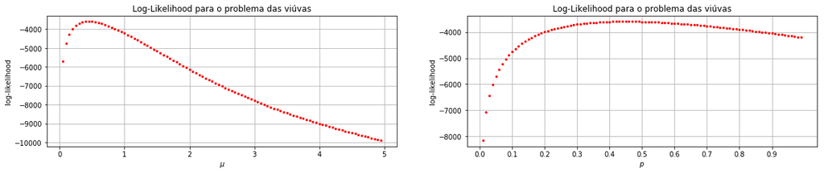

```python
# Widows Data
y0 = 3062; y1 = 587; y2 = 284; y3 = 103; y4 = 33; y5 = 4; y6 = 2
y = [y0, y1, y2, y3, y4, y5, y6]

# Parameters
mu = np.arange(0.05,5, 0.05)
p = np.arange(0.01, 1, 0.01)

fig, ax = plt.subplots(1, 2, figsize=(20, 3.5))
# Plot para $\mu$
ax[0].plot(mu, [log_likelihood(y, m, 0.1) for m in mu], 'ro', ms=2.5);
plt.xticks([i+0.5 for i in range(0, 5)])
ax[0].set_title('Log-Likelihood para o problema das viúvas');
ax[0].set_xlabel('$\mu$'); ax[0].grid()
ax[0].set_ylabel('log-likelihood');

# Plot para $p$
ax[1].plot(p, [log_likelihood(y, prob, 0.1) for prob in p], 'ro', ms=2.5);
ax[1].set_xlabel('$p$'); ax[1].grid(); ax[1].set_title('Log-Likelihood para o problema das viúvas')
ax[1].set_xticks([0.1*i for i in range(0,10)]);ax[1].set_ylabel('log-likelihood')
plt.show()
```

Para utilizar o algoritmo de Newton-Raphson, define-se,

$$f(\theta) = y_0 \log \left(p + (1-p)e^{-\mu}\right) +\sum_{k=1}^6 \left[y_k \left(\log(1-p) + k\log \mu - \mu -\log(k!) \right)\right] $$

E as iterações serão dadas por, $$\theta_{t+1} = \theta_{t} - H^{-1}\left[f\right](\theta_t) \nabla f(\theta_t), \text{ onde } \theta_t = (p_t, \mu_t)$$

Tal que,

$$\nabla f(\theta_t) = [\partial f/\partial p, \partial f/ \partial \mu]^T = \left[y_0 \frac{e^{\mu_t}-1}{1+p_t(e^{\mu_t} - 1)} + \sum_{k=1}^6 y_k \frac{1}{p_t-1}, \frac{y_0(p_t-1)}{1+p_t(e^{\mu_t} - 1)} + \sum_{k=1}^6 y_k \left(\frac{k}{\mu_t}-1 \right) \right]^T$$

E também temos que,

$$ \frac{\partial ^2 f} {\partial p \partial \mu} = \frac{y_0 e^\mu}{\left(p(e^\mu -1) +1\right)^2}, \qquad \frac{\partial ^2 f}{\partial p ^2} = \frac{y_0 (e^\mu -1)^2}{\left( p (e^\mu -1) +1\right)^2} - \sum_{k=1}^6 \frac{y_k}{(1-p)^2}, \qquad \frac{\partial ^2 f}{\partial \mu ^2} = \frac{y_0 p (1-p) e^\mu }{(p(e^\mu -1)+1)^2} - \sum_{k=1}^6 \frac{ky_k}{\mu^2} $$

E portanto a hessiana é dada por,

$$H[f](\theta_t)= \begin{bmatrix} \frac{\partial ^2 f(\theta_t)}{\partial p ^2} \ \frac{\partial ^2 f(\theta_t)}{\partial p \partial \mu} \\ \frac{\partial ^2 f(\theta_t)}{\partial \mu \partial p} \ \frac{\partial ^2 f(\theta_t)}{\partial \mu ^2} \\ \end{bmatrix} $$

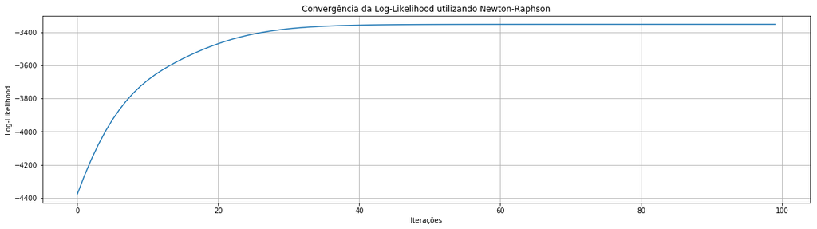

```
O Método de Newton-Raphson convergiu para (p, mu) = (0.611892010267855, 1.022899526996681).
```

```python
def hessian(Y, p, mu):
    d2f_dp2 =  Y[0]*(np.exp(mu)-1)**2 / ((p*(np.exp(mu)-1)+1)**2) - sum(Y[1:])/((1-p)**2)
    d2f_dpdu = Y[0]*np.exp(mu)/(p*(np.exp(mu)-1)+1)**2
    d2f_du2 = Y[0]*p*(1-p)*np.exp(mu)/((p*(np.exp(mu)-1)+1)**2 )- sum([Y[k]*k/(mu**2) for k in range(1,6)])
    H = [
        [d2f_dp2, d2f_dpdu],
        [d2f_dpdu, d2f_du2]
    ]
    return H

def gradient(Y, p, mu):
    grad = [
        Y[0]*(np.exp(mu)-1)/(1+p*(np.exp(mu)-1)) + (1/(p-1))*sum(Y[1:]),
        Y[0]*(p-1)/(1+p*(np.exp(mu)-1)) + sum([Y[k]*(k/mu - 1) for k in range(1,6)])
    ]
    return grad

# Newton-Raphson
iterations_newton = []
num_of_it = 0
p, mu = 0.6, 0.2
theta = (p, mu)
gamma = 0.1
for i in range(0,100):
    theta = tuple(theta - gamma*np.matmul(np.linalg.inv(hessian(y, theta[0], theta[1])), gradient(y, theta[0], theta[1])))
    iterations_newton.append(theta)

# Plot da convergência
plt.figure(figsize=(20,5))
plt.grid()
plt.plot([i for i in range(0,len(iterations_newton))],
         [log_likelihood(y, iterations_newton[i][1], iterations_newton[i][0]) for i in range(len(iterations_newton))])
plt.title('Convergência da Log-Likelihood utilizando Newton-Raphson')
plt.xlabel('Iterações')
plt.ylabel('Log-Likelihood')
plt.show()
print('O Método de Newton-Raphson convergiu para (p, mu) = {}.'.format(iterations_newton[-1]))
```

**(b)** Os dados completos, agora com a separação das viúvas $y_0$ em duas populações $x_A$ e $x_B$, são dados por,

$$ L^C(Y|\theta)= p^{x_A} + \left[ (1-p)e^{\mu}\right]^{x_B} + \prod_{k=1}^{6} \left[ (1-p) \frac{\mu^k e^{-\mu}}{k!} \right]^{y_k} $$

E portanto, o log da verossimilhança dos dados completos é,

$$ \log L^C(Y|\theta)= x_A \log(p) + x_B \left[\log (1-p) - \mu \right] + \sum_{k=1}^6 y_k \left[\log(1-p) + k \log(\mu) -\mu - \log(k!) \right] $$

Portanto, o E-Step é dado por,

$$x_{A}^{(t)} = y_0 \frac{p^{(t)}}{p^{(t)} + e^{-\mu ^{(t)}}(1-p^{(t)})} \ \ \text{ e } \ \ x_{B}^{(t)} = y_0 \left[1 - \frac{p^{(t)}}{p^{(t)} + e^{\mu ^{(t)}}(1-p^{(t)})} \right]$$

e o M-Step será dado por,

$$ p^{(t+1)} = \frac{x_{A}^{(t)}}{y_0 + \sum_{k=1}^6 y_k} \ \ \text{ e } \ \ \mu^{(t+1)} = \frac{\sum_{k=1}^6 y_k \times k }{x_B^{(t)} + \sum_{k=1}^6 y_k} $$

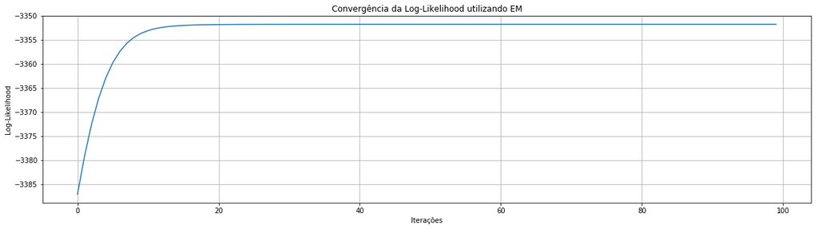

```
O Método EM convergiu para (p, mu) = (0.61122781081080479, 1.0200431723394876).
```

```python
def xA(Y, p, mu):
    return Y[0]*p/(p+np.exp(-mu)*(1-p))

def xB(Y, p, mu):
    return Y[0] - xA(Y, p, mu)

p, mu = 0.6, 0.2
theta = (p, mu)
iterations_em = []
for i in range(0,100):
    new_p = xA(y, p, mu)/(y[0] + sum(y[1:]))
    new_mu = sum([k*y[k] for k in range(1,6)])/(xB(y, p, mu) + sum(y[1:]))

    p = new_p
    mu = new_mu

    iterations_em.append((p, mu))

# Plot da convergência
plt.figure(figsize=(20,5))
plt.grid()
plt.plot([i for i in range(0,len(iterations_em))],
         [log_likelihood(y, iterations_em[i][1], iterations_em[i][0]) for i in range(len(iterations_em))])
plt.title('Convergência da Log-Likelihood utilizando EM')
plt.xlabel('Iterações')
plt.ylabel('Log-Likelihood')
plt.show()
print('O Método EM convergiu para (p, mu) = {}.'.format(iterations_em[-1]))
```

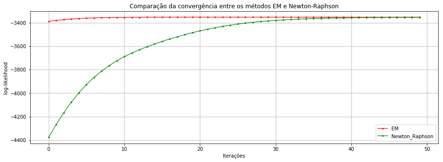

```
Nota-se que o método EM converge muito mais rapidamente que o método de Newton.
```

```python
# Comparação entre ambos os métodos
n = 50
plt.figure(figsize=(15,5))
plt.grid()

plt.plot([i for i in range(0,n)],
         [log_likelihood(y, iterations_em[i][1], iterations_em[i][0]) for i in range(n)], 'ro-', alpha=0.8, ms=2.5,
        label='EM')
plt.plot([i for i in range(0,n)],
         [log_likelihood(y, iterations_newton[i][1], iterations_newton[i][0]) for i in range(n)], 'go-', alpha=0.8, ms=2.5,
        label='Newton_Raphson')
plt.title('Comparação da convergência entre os métodos EM e Newton-Raphson')
plt.ylabel('log-likelihood')
plt.xlabel('Iterações')
plt.legend()
plt.show()
print('Nota-se que o método EM converge muito mais rapidamente que o método de Newton.')
```

**Exercício 1.2**

**(a)** Primeiramente, podemos plotar o gráfico da função de verossimilhança para verificarmos sua topologia, e facilitar a visualização dos pontos iniciais que serão utilizados para o método iterativo.

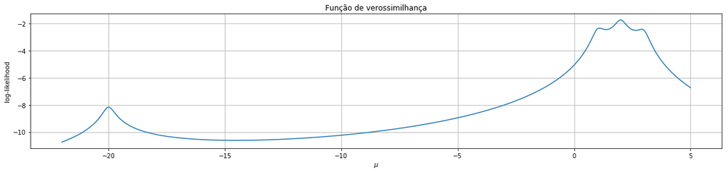

```python
def likelihood(mu):
    Y = [-20, 1, 2, 3]
    k = 0
    for i in range(0,len(Y)):
        k += np.log(0.05 + np.power(Y[i] - mu, 2))
    return -0.525*k

# Dando valores para mu
mu = np.arange(-22, 5, 0.00005)

# Plotando o gráfico
plt.figure(figsize=(20,4)); plt.grid(); plt.plot(mu, likelihood(mu))
plt.title('Função de verossimilhança'); plt.xlabel('$\mu$'); plt.ylabel('log-likelihood'); plt.show()
```

Agora podemos utilizar o método iterativo de Newton-Raphson, com um fator $\alpha \in (0,1)$ multiplicativo, dado por,

$$ \mu^{(t+1)} = \mu^{(t)} - \alpha \frac{\left(\frac{\partial \log L(\mu^{(t)}|y)}{\partial \mu^{(t)}} \right)}{\left(\frac{\partial^2 \log L(\mu^{(t)}|y)}{\partial \mu^{(t)^2}} \right)} $$

```python
# derivada da verossimilhança
def d_likelihood(mu):
    Y = [-20, 1, 2, 3]
    k = 0
    for i in range(0,len(Y)):
        k += -2*(Y[i] - mu)/((Y[i] - mu)**2 + 0.05)
    return -0.525*k

# derivada segunda da verossimilhança
def d2_likelihood(mu):
    Y = [-20, 1, 2, 3]
    k = 0
    for i in range(0,len(Y)):
        k += -2*(mu**2 - 2*mu*Y[i] + Y[i]**2 - 0.05)/(mu**2 - 2*mu*Y[i] + Y[i]**2 + 0.05)**2
    return -0.525*k
```

Abaixo, utiliza-se o valor inicial $\mu^{(0)}=-5$ e $\alpha = 0.05$, conseguimos achar o máximo local $\mu_4\approx 2.9085$

```
Convergência para mu = 2.9085536666098712
```

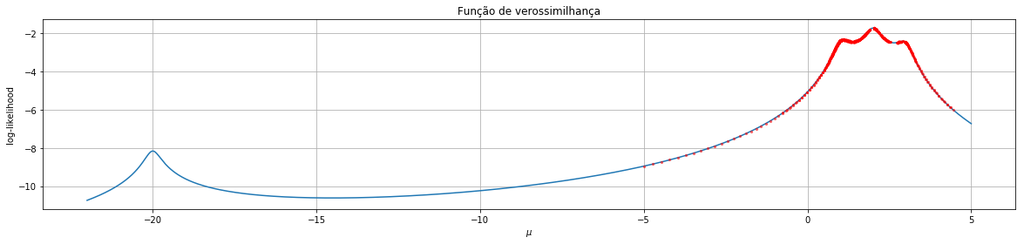

```python
mu = -5

m = [mu]
l = [likelihood(mu)]
alpha = 0.05

epsilon = 0.00001
i = 0
l_cur = np.float('inf')
while abs(l_cur - l[i-1]) > epsilon:
    mu = mu + alpha*d_likelihood(mu)/d2_likelihood(mu)
    l_cur = likelihood(mu)
    m.append(mu)
    l.append(l_cur)
    i += 1

# Dando valores para mu
mu2 = np.arange(-22, 5, 0.00005)

# Plotando o gráfico
print('Convergência para mu =', mu)
plt.figure(figsize=(20,4)); plt.grid(); plt.plot(mu2, likelihood(mu2));plt.plot(m, l, 'ro', ms=2.2, alpha=0.5)
plt.title('Função de verossimilhança'); plt.xlabel('$\mu$'); plt.ylabel('log-likelihood'); plt.show()
```

Abaixo, utiliza-se o valor inicial $\mu^{(0)}=-22$ e $\alpha = 0.05$, conseguimos achar o máximo local $\mu_3\approx 1.9954$

```
Convergência para mu = 1.9954670269685384
```

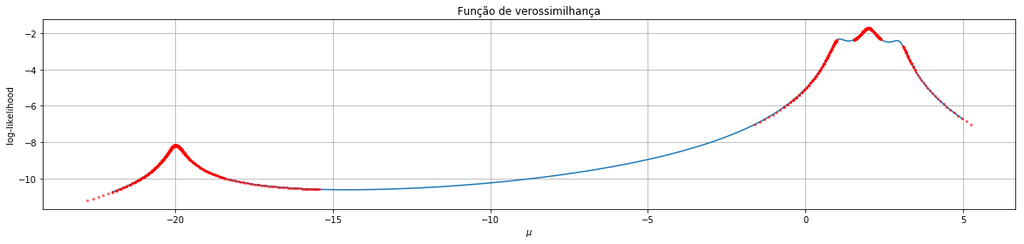

```python
mu = -22

m = [mu]
l = [likelihood(mu)]
alpha = 0.05

epsilon = 0.00001
i = 0
l_cur = np.float('inf')
while abs(l_cur - l[i-1]) > epsilon:
    mu = mu + alpha*d_likelihood(mu)/d2_likelihood(mu)
    l_cur = likelihood(mu)
    m.append(mu)
    l.append(l_cur)
    i += 1

# Dando valores para mu
mu2 = np.arange(-22, 5, 0.00005)

# Plotando o gráfico
print('Convergência para mu =', mu)
plt.figure(figsize=(20,4)); plt.grid(); plt.plot(mu2, likelihood(mu2));plt.plot(m, l, 'ro', ms=2.2, alpha=0.5)
plt.title('Função de verossimilhança'); plt.xlabel('$\mu$'); plt.ylabel('log-likelihood'); plt.show()
```

Abaixo, utiliza-se o valor inicial $\mu^{(0)}=-50$ e $\alpha = 0.05$, conseguimos achar o máximo local $\mu_1\approx -19.9947$

```
Convergência para mu = -19.994782416295784
```

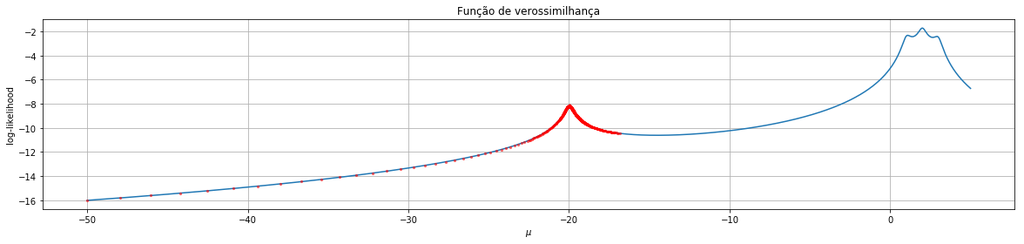

```python
mu = -50

m = [mu]
l = [likelihood(mu)]
alpha = 0.05

epsilon = 0.00001
i = 0
l_cur = np.float('inf')
while abs(l_cur - l[i-1]) > epsilon:
    mu = mu + alpha*d_likelihood(mu)/d2_likelihood(mu)
    l_cur = likelihood(mu)
    m.append(mu)
    l.append(l_cur)
    i += 1

# Dando valores para mu
mu2 = np.arange(-50, 5, 0.00005)

# Plotando o gráfico
print('Convergência para mu =', mu)
plt.figure(figsize=(20,4)); plt.grid(); plt.plot(mu2, likelihood(mu2));plt.plot(m, l, 'ro', ms=2.2, alpha=0.5)
plt.title('Função de verossimilhança'); plt.xlabel('$\mu$'); plt.ylabel('log-likelihood'); plt.show()
```

```
Convergência para mu = 1.0820117562619147
```

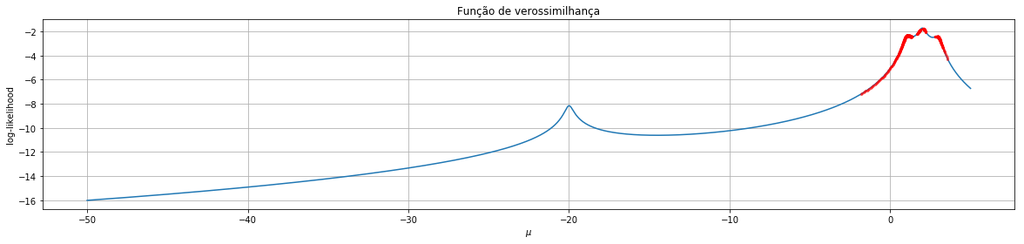

```python
mu = 0.5

m = [mu]
l = [likelihood(mu)]
alpha = 0.05

epsilon = 0.00001
i = 0
l_cur = np.float('inf')
while abs(l_cur - l[i-1]) > epsilon:
    mu = mu + alpha*d_likelihood(mu)/d2_likelihood(mu)
    l_cur = likelihood(mu)
    m.append(mu)
    l.append(l_cur)
    i += 1

# Dando valores para mu
mu2 = np.arange(-50, 5, 0.00005)

# Plotando o gráfico
print('Convergência para mu =', mu)
plt.figure(figsize=(20,4)); plt.grid(); plt.plot(mu2, likelihood(mu2));plt.plot(m, l, 'ro', ms=2.2, alpha=0.5)
plt.title('Função de verossimilhança'); plt.xlabel('$\mu$'); plt.ylabel('log-likelihood'); plt.show()
```

**(c)** Seja a recursão definida pelo algoritmo EM ser definida por,

$$ \mu^{(k)} = \frac{\sum_{i=1}^4 y_i \phi_i(\mu^{(k-1)})}{\sum_{i=1}^4 \phi_i(\mu^{(k-1)})} \qquad \text{em que} \qquad \phi_i(\mu) = 1.05(0.05 + (y_i - \mu)^2)^{-1} $$

```python
# Definindo a função phi
def phi(mu, i, Y):
    return 1.05/(0.05 + (Y[i] - mu)**2)

# Criando os valores iniciais mu^0 para o qual a recursão do algoritmo EM será inicializado
starting_values = [-30, -18, 1.5, 2.5, 30]

# Para cada valor inicial, iremos utilizar a recursão definida anteriomente
for initial_value in starting_values:
    # Aqui inicializa-se a recursão
    mu = [initial_value]
    for k in range(1,50):
        mu_k = sum([y[i]*phi(mu[k-1], i, y) for i in range(0, len(y))]) / sum([phi(mu[k-1], i, y) for i in range(0, len(y))])
        mu.append(mu_k)
        # Se convergimos, pare de iterar
        if abs(mu[k] - mu[k-1]) < 0.0001:
            break
    print('Quando inicializa-se com o valor inicial de mu = {}, convergimos para {}'.format(initial_value, mu[-1]))
```

```
Quando inicializa-se com o valor inicial de mu = -30, convergimos para 3.977305494956227
Quando inicializa-se com o valor inicial de mu = -18, convergimos para 3.9773087957590127
Quando inicializa-se com o valor inicial de mu = 1.5, convergimos para 2.0278464319332294
Quando inicializa-se com o valor inicial de mu = 2.5, convergimos para 2.027845625926402
Quando inicializa-se com o valor inicial de mu = 30, convergimos para 32.99768284518233
```

Portanto, aplicando a recursão e utilizando os valores iniciais fornecidos no item (c), não conseguimos atingir o máximo local $\mu_4=2.906$ apenas.

**Exercício 2 -** Ising Model with Periodic External Field

O problema irá definir o grid $\mathbb{Z}^2$, e separará esse grid em dois campos externos diferentes, definidos por dois conjuntos mutuamente exclusivos denominados $Z_-$ e $Z_+$.

- Os pontos que pertencem ao conjunto $Z_-$ possuem campo de valor $-h_-$
- Os pontos que pertencem ao conjunto $Z_+$ possuem valor de $h_+$

Um exemplo para ilustrar o problema é dado na figura abaixo, em que $L = 3, l = 1$ (e ignorando $n, m < 1$ e $n, m > 2$).

[figure not shown]

**(a)** O algoritmo de Metropolis-Hasting, usando uma função proposta simétrica (lançamento de moeda), é dado por:

1. Inicializar $\sigma^{0}$
2. Repetir para $k = 0$ até $N$:
   - Amostrar $(i,j) = (\lfloor u_1 \rfloor$, $\lfloor u_2 \rfloor$), em que $u_1$ ~ $U[mL, (m+1)L - 1]$ e $u_2$ ~ $U[nL, (n+1)L - 1]$
   - Amostrar $p$ ~ Bernoulli$\left(\frac{1}{2}\right)$
   - Amostrar $\sigma^*$, em que $\sigma^*_{(m,n)} =$ $ \begin{cases} \sigma^{k}_{(m,n)},& \text{se } (m,n) \neq (i,j) \\ -\sigma^{k}_{(i,j)},& \text{se } (m,n) = (i,j) \text{ e } p \geq \frac{1}{2}\\ +\sigma^{k}_{(i,j)},& \text{se } (m,n) = (i,j) \text { e } p < \frac{1}{2}\\ \end{cases} $
   - Amostrar $u$ ~ $U[0,1]$

     2.1 Se $u < \rho(\sigma^k, \sigma^*) = \min \left\{1, e^{-\beta \left(H(\sigma^*) - H(\sigma^k)\right) }\right\}$:

     $\sigma^{k+1} = \sigma^*$,

     Senão,

     $\sigma^{k+1} = \sigma^{k}$
3. Fim

Ressaltando que, $$ e^{-\beta \left(H(\sigma^*) - H(\sigma^k)\right) } = \exp\left[-\beta\left(-\sum_{<t,s>} \sigma^*_t \sigma^*_s - \sum_t h_t\sigma^*_t + \sum_{<t,s>} \sigma_s^k\sigma_t^k + \sum_t h_t\sigma^k_t\right)\right] $$

**(b)** Supondo que tenhamos $\sigma=[\sigma_1, \sigma_2, \sigma_3, \sigma_4] = [\sigma_{(1,1)}, \sigma_{(1,2)},\sigma_{(2,1)}, \sigma_{(2,2)}]$, então pode-se utilizar a amostragem de Gibbs, dada por,

$$\sigma_1|\sigma^{k-1}_2,...,\sigma^{k-1}_M \longrightarrow \sigma_2|\sigma^{k-1}_1,\sigma^{k-1}_3,...,\sigma^{k-1}_M \longrightarrow ........ \longrightarrow \sigma_M|\sigma^{k-1}_1, ..., \sigma^{k-1}_{M-1} \qquad \text{ em que } \sigma_i^k \in \sigma^k \text { onde } i \in \mathbb{Z}^2 \text{ e } k \text{ representa a k-ésima iteração.}$$

Para utilizar a amostragem de Gibbs, podemos começar escrevendo,

$$ P(\sigma) = P(\sigma_1, \sigma_2,\sigma_3,\sigma_4) = \frac{\exp\left[-\beta H(\sigma_1, \sigma_2, \sigma_3, \sigma_4) \right]}{K} $$

E para conseguirmos amostrar $\sigma_1$, (vamos ignorar o sobrescrito $k$, que representa as iterações, para simplificar as contas)

$$ P(\sigma_1 | \sigma_2, \sigma_3, \sigma_4) = \frac{\frac{P(\sigma_1, \sigma_2, \sigma_3, \sigma_3)}{K}}{\frac{P(\sigma_2, \sigma_3, \sigma_4)}{K}} = \frac{P(\sigma_1, \sigma_2, \sigma_3, \sigma_3)}{P(\sigma_2, \sigma_3, \sigma_4)} $$

Podemos então expandir a equação acima, tal que,

$$ P(\sigma_1|\sigma_2, \sigma_3, \sigma_4) = P(\sigma_{(1,1)}|\sigma_{(1,2)}, \sigma_{(2,1)}, \sigma_{(2,2)}) \\ = \frac{ \exp\left[ \beta \left( ( \sigma_{(1,1)}\sigma_{(1,2)} + \sigma_{(1,1)}\sigma_{(2,1)} ) + ( \sigma_{(1,2)}\sigma_{(1,1)} + \sigma_{(1,2)}\sigma_{(2,2)} ) + ( \sigma_{(2,1)}\sigma_{(1,1)} + \sigma_{(2,1)}\sigma_{(2,2)} ) + ( \sigma_{(2,2)}\sigma_{(1,2)} + \sigma_{(2,2)}\sigma_{(2,1)} ) + ( h_{(1,1)}\sigma_{(1,1)} + h_{(1,2)}\sigma_{(1,2)} + h_{(2,1)}\sigma_{(2,1)} + h_{(2,2)}\sigma_{(2,2)}) \right) \right] } { \exp\left[ \beta \left( ( \sigma_{(1,2)}\sigma_{(2,2)} ) + ( \sigma_{(2,2)}\sigma_{(2,1)} + \sigma_{(2,2)}\sigma_{(1,2)} ) + ( \sigma_{(2,1)}\sigma_{(2,2)} ) + ( h_{(1,2)}\sigma_{(1,2)} + h_{(2,1)}\sigma_{(2,1)} + h_{(2,2)}\sigma_{(2,2)}) \right) \right] } $$

E portanto, teremos que,

$$ P(\sigma_1|\sigma_2, \sigma_3, \sigma_4) = \exp\left[ \beta\left( \sigma_{(1,1)}\sigma_{(1,2)} + \sigma_{(1,1)}\sigma_{(2,1)} + \sigma_{(1,2)}\sigma_{(1,1)} + \sigma_{(2,1)}\sigma_{(1,1)} + h_{(1,1)}\sigma_{(1,1)}) \right)\right] = \exp\left[ \beta \sigma_{(1,1)} \left(2\sigma_{(1,2)} + 2\sigma_{(2,1)} + h_{(1,1)}\right) \right] $$

Ou seja,

$$ P(\sigma_1|\sigma_2, \sigma_3, \sigma_4) = \exp\left[\beta \sigma_1 \left( 2\sigma_2 + 2 \sigma_3 + h_1\right)\right] $$

Nota-se que $\sigma_1$ é vizinho apenas de $\sigma_2$ e $\sigma_3$, e que pode se ignorar o campo externo de todos os outros pontos. É claro que pode-se generalizar esse resultado para qualquer $\sigma_i$, e fazemos escrevendo,

$$ P(\sigma_i | \sigma_{\{j \neq i\} \in \Pi}) = \exp\left[\beta \sigma_i \left(2 \partial \sigma_i + h_i\right) \right] $$

Em que $\partial \sigma_i = \{\sigma_j : \langle i,j \rangle \}$, ou seja, a amostragem para $\sigma_i$ depende tão somente de seu próprio campo externo e da soma da energia de seus vizinhos.

O algoritmo, pode ser descrito como:

1. Inicializar $\sigma^{0}$
2. Para $k=1$ até N:

   2.1 Para cada ponto $i \in \Pi$:
   - Tomamos $J(\sigma^k_i) = \exp\left[\beta \sigma_i^{(k-1)} \left(2 \partial \sigma_i^{(k-1)} + h_i\right) \right]$
   - Fazemos que $p = \frac{J(\sigma^k_i)}{1+J(\sigma^k_i)}$ (Isto é, o odds da distribuição de Gibbs)
   - $\sigma^k_i = \begin{cases} \sigma^{(k-1)}_i, \text{ se } p \geq 1/2 \\ -\sigma^{(k-1)}_i, \text { se } p < 1/2 \end{cases}$
3. Fim

**(c, d)** Aqui neste caso, nossa taxa de aceitação será dada por,

$$ p(\sigma^*, \sigma^k) = \exp\left[ -\frac{\Delta E}{T} \right] \qquad \Delta E = H(\sigma^*) - H(\sigma^k) $$

E para acharmos a configuração $\sigma_{\min}$ de energia mínima, queremos resolver,

$$ \sigma_{\min} = \arg \min _{\sigma} H(\sigma) $$

Para isso, utilizamos o simulated annealing da seguinte forma,

1. Inicializar $\sigma, T$
2. Enquanto $T > T_{\min}$:
   - Amostrar $(i,j) = (\lfloor u_1 \rfloor$, $\lfloor u_2 \rfloor$), em que $u_1$ ~ $U[mL, (m+1)L - 1]$ e $u_2$ ~ $U[nL, (n+1)L - 1]$
   - Amostrar $p$ ~ Bernoulli$\left(\frac{1}{2}\right)$
   - Amostrar $\sigma^*$, em que $\sigma^*_{(m,n)} =$ $ \begin{cases} \sigma_{(m,n)},& \text{se } (m,n) \neq (i,j) \\ -\sigma_{(i,j)},& \text{se } (m,n) = (i,j) \text{ e } p \geq \frac{1}{2}\\ +\sigma_{(i,j)},& \text{se } (m,n) = (i,j) \text { e } p < \frac{1}{2}\\ \end{cases} $
   - Amostrar $u$ ~ $U[0,1]$

     2.1. Se $u < \rho(\sigma, \sigma^*) = \min \left\{1, \exp\left[ -\frac{\Delta E}{T} \right] \right\}$:

     $\sigma = \sigma^*$,

     Senão,

     $\sigma = \sigma$

Abaixo, temos o código das simulações para o Simulated Annealing, e as simulações em si.

À esquerda, utilizou-se $l=5$, à direita utiliza-se $l=8$.

[figure not shown]

```python
# Criação das funções que serão utilizadas para a simulação

# Inicia o grid
def initial_grid(L):
    grid = np.zeros((L,L))
    spin = [-1,1]
    for i in range(len(grid)):
        for j in range(len(grid[i])):
            u = np.random.randint(0,2)
            grid[i][j] = spin[u]
    return grid

# Função auxiliar para encontrar os vizinhos de um ponto
def find_neighbors(grid, x):
    '''
    params:
        grid = matrix n por n
        x = tupla (i,j)
    Dado um grid, e um ponto x retorna uma lista de tuplas, cada tupla tem as coordenadas do vizinho de x

    returns:
        neighbors = [(i-1, j), (i+1, j), (i, j-1), (i, j+1)] # as coordenadas dependem da localização do ponto x
    '''
    neighbors = []
    (i, j) = x
    if (i, j) == (0, 0):
        n1, n2 = (i, j+1), (i+1, j); neighbors = [n1, n2]
    if i != 0 and i != len(grid)-1 and j == 0:
        n1, n2, n3 = (i-1, j), (i, j+1), (i+1, j); neighbors = [n1, n2, n3]
    if i == len(grid)-1 and j == 0:
        n1, n2 = (i, j+1), (i-1, j); neighbors = [n1, n2]
    if i == 0 and j != 0 and j != len(grid[i])-1:
        n1, n2, n3 = (i, j-1), (i+1, j), (i, j+1); neighbors = [n1, n2, n3]
    if i != 0 and i != len(grid) and j != 0 and j != len(grid[i])-1:
        n1, n2, n3, n4 = (i-1, j), (i+1, j), (i, j-1), (i, j+1); neighbors = [n1, n2, n3, n4]
    if i == len(grid)-1 and j != 0 and j != len(grid[i])-1:
        n1, n2, n3 = (i, j-1), (i-1, j), (i, j+1); neighbors = [n1, n2, n3]
    if i == 0 and j == len(grid[i])-1:
        n1, n2 = (i, j-1), (i+1, j); neighbors = [n1, n2]
    if i != 0 and i != len(grid) and j == len(grid[i])-1:
        n1, n2, n3 = (i, j-1), (i+1, j), (i-1, j); neighbors = [n1, n2, n3]
    if i == len(grid)-1 and j == len(grid[i])-1:
        n1, n2 = (i-1, j), (i, j-1); neighbors = [n1, n2]
    return neighbors

# Calcula a diferença de energia $\Delta E$, que é a diferença entre a hamiltoniana proposta e a hamiltoniana do estado atual
def dE(grid_s, grid_k, h):
    hamiltonian = 0
    for i in range(len(grid_s)):
        for j in range(len(grid_s[i])):
            hamiltonian -= h[(i,j)]*(grid_s[i][j] - grid_k[i][j])
            for neighbors in find_neighbors(grid_s, (i,j)):
                (m, n) = neighbors
                hamiltonian -= grid_s[i][j]*grid_s[m][n] - grid_k[i][j]*grid_k[m][n]
    return hamiltonian

# Calcula o campo externo para ser imputado na hamiltoniana
def create_fields(grid, L, l):
    import itertools
    # Criando Z_negativo
    j = 0
    m = []
    for i in range(0, len(grid)):
        j+=1
        if i%10==0:
            j=0
        if j < l:
            m.append(i)
    z_neg = list(itertools.product(m, m))
    # Criando Z_positivo
    a = [i for i in range(len(grid))]
    Z2 = set(itertools.product(a,a))
    z_pos = Z2.difference(set(z_neg))
    return z_neg, list(z_pos)
```

```python
# parâmetros inciais
L = 10
l = 5
h_val = 1

import copy
# criando o grid inicial
grid = initial_grid(10*L)

# criando o campo externo
z_neg, z_pos = create_fields(grid, L, l)
h = {}
for zn in z_neg:
    h[zn] = -h_val
j = []
for zp in z_pos:
    h[zp] = (h_val * l**2)/(L**2 - l**2)

# inicializando a simulação
grid = np.ones((10*L,10*L))
T = 50000
num_of_changes = 100
sigmas = []
num_iters = 0

while T > 0.1:
    # vai diminuindo o número de mudanças dos spins a cada 2 iterações
    if num_iters%2==0 and num_of_changes > 10:
        num_of_changes-=1

    # criam-se duas variáveis aleatorias uniformes no grid para alterar o valor do spin
    grid_s = copy.deepcopy(grid)
    for i in range(int(num_of_changes)):
        u = np.random.randint(0, len(grid), 2)
        grid_s[u[0]][u[1]] = -grid_s[u[0]][u[1]]

    # critério de aceitação
    u = np.random.uniform(0,1)
    delta_e = -dE(grid_s, grid, h)
    if u < min(1, np.exp(delta_e/T)):
        grid = grid_s
        sigmas.append(grid)

    # atualização da temperatura
    T = .9*T
    num_iters+=1
```

```python
# parâmetros inciais
L = 10
l = 8
h_val = 1

import copy
# criando o grid inicial
grid = initial_grid(10*L)

# criando o campo externo
z_neg, z_pos = create_fields(grid, L, l)
h = {}
for zn in z_neg:
    h[zn] = -h_val
j = []
for zp in z_pos:
    h[zp] = (h_val * l**2)/(L**2 - l**2)

# inicializando a simulação
grid = np.ones((10*L,10*L))
T = 50000
num_of_changes = 100
sigmas_2 = []
num_iters = 0

while T > 0.1:
    # vai diminuindo o número de mudanças dos spins a cada 2 iterações
    if num_iters%2==0 and num_of_changes > 10:
        num_of_changes-=1

    # criam-se duas variáveis aleatorias uniformes no grid para alterar o valor do spin
    grid_s = copy.deepcopy(grid)
    for i in range(int(num_of_changes)):
        u = np.random.randint(0, len(grid), 2)
        grid_s[u[0]][u[1]] = -grid_s[u[0]][u[1]]

    # critério de aceitação
    u = np.random.uniform(0,1)
    delta_e = -dE(grid_s, grid, h)
    if u < min(1, np.exp(delta_e/T)):
        grid = grid_s
        sigmas_2.append(grid)

    # atualização da temperatura
    T = .9*T
    num_iters+=1
```

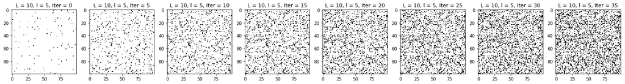

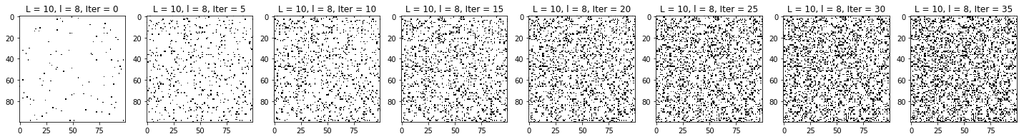

```python
import matplotlib as mpl
fig, ax = plt.subplots(1, 8)
fig.set_size_inches(25, 25)
cmap = mpl.colors.ListedColormap(['k', 'w'])
bounds = [0., 0.5, 1.]
norm = mpl.colors.BoundaryNorm(bounds, cmap.N)
for i in range(0,8):
    ax[i].imshow(sigmas[5*i], interpolation='none', cmap=cmap, norm=norm)
    ax[i].set_title('L = 10, l = 5, Iter = {}'.format(5*i))

plt.show()

fig, ax = plt.subplots(1, 8)
fig.set_size_inches(25, 25)
cmap = mpl.colors.ListedColormap(['k', 'w'])
bounds = [0., 0.5, 1.]
norm = mpl.colors.BoundaryNorm(bounds, cmap.N)
for i in range(0,8):
    ax[i].imshow(sigmas_2[5*i], interpolation='none', cmap=cmap, norm=norm)
    ax[i].set_title('L = 10, l = 8, Iter = {}'.format(5*i))
plt.show()
```